# Advanced_ML_Project_EasyVisa_Jan26_DebasishNanda_001

[figure not shown]

Artificial Intelligence and Machine Learning

Ensemble Techniques and Model Tuning

[figure not shown]

Visa Approval Facilitation

# **Problem Statement**

## Context

Business communities in the United States are facing high demand for human resources, but one of the constant challenges is identifying and attracting the right talent, which is perhaps the most important element in remaining competitive. Companies in the United States look for hard-working, talented, and qualified individuals both locally as well as abroad.

The Immigration and Nationality Act (INA) of the US permits foreign workers to come to the United States to work on either a temporary or permanent basis. The act also protects US workers against adverse impacts on their wages or working conditions by ensuring US employers' compliance with statutory requirements when they hire foreign workers to fill workforce shortages. The immigration programs are administered by the Office of Foreign Labor Certification (OFLC).

OFLC processes job certification applications for employers seeking to bring foreign workers into the United States and grants certifications in those cases where employers can demonstrate that there are not sufficient US workers available to perform the work at wages that meet or exceed the wage paid for the occupation in the area of intended employment.

## Objective

In FY 2016, the OFLC processed 775,979 employer applications for 1,699,957 positions for temporary and permanent labor certifications. This was a nine percent increase in the overall number of processed applications from the previous year. The process of reviewing every case is becoming a tedious task as the number of applicants is increasing every year.

The increasing number of applicants every year calls for a Machine Learning based solution that can help in shortlisting the candidates having higher chances of VISA approval. OFLC has hired the firm EasyVisa for data-driven solutions. You as a data scientist at EasyVisa have to analyze the data provided and, with the help of a classification model:

- Facilitate the process of visa approvals.
- Recommend a suitable profile for the applicants for whom the visa should be certified or denied based on the drivers that significantly influence the case status.

## Data Description

The data contains the different attributes of employee and the employer. The detailed data dictionary is given below.

- case_id: ID of each visa application
- continent: Information of continent the employee
- education_of_employee: Information of education of the employee
- has_job_experience: Does the employee has any job experience? Y= Yes; N = No
- requires_job_training: Does the employee require any job training? Y = Yes; N = No
- no_of_employees: Number of employees in the employer's company
- yr_of_estab: Year in which the employer's company was established
- region_of_employment: Information of foreign worker's intended region of employment in the US.
- prevailing_wage: Average wage paid to similarly employed workers in a specific occupation in the area of intended employment. The purpose of the prevailing wage is to ensure that the foreign worker is not underpaid compared to other workers offering the same or similar service in the same area of employment.
- unit_of_wage: Unit of prevailing wage. Values include Hourly, Weekly, Monthly, and Yearly.
- full_time_position: Is the position of work full-time? Y = Full Time Position; N = Part Time Position
- case_status: Flag indicating if the Visa was certified or denied

## Note: This is a sample solution for the project. Projects will NOT be graded on the basis of how well the submission matches this sample solution. Projects will be graded on the basis of the rubric only.

# **Importing necessary libraries**

```python
# Installing the libraries with the specified version.
!pip install numpy==2.0.2 pandas==2.2.2 scikit-learn==1.6.1 matplotlib==3.10.0 seaborn==0.13.2 xgboost==3.0.5 -q --user
```

```
   ━━━━━━━━━━━━━━━━━━━━━━━━━━━━━━━━━━━━━━━━ 94.9/94.9 MB 6.9 MB/s eta 0:00:00
```

**Note**: *After running the above cell, kindly restart the notebook kernel and run all cells sequentially from the start again.*

```python
import warnings
warnings.filterwarnings("ignore")

# Libraries to help with reading and manipulating data
import numpy as np
import pandas as pd

# Library to split data
from sklearn.model_selection import train_test_split

# Libraries to help with data visualization
import matplotlib.pyplot as plt
import seaborn as sns

# Removes the limit for the number of displayed columns
pd.set_option("display.max_columns", None)
# Sets the limit for the number of displayed rows
pd.set_option("display.max_rows", 100)

# To oversample and undersample data
from imblearn.over_sampling import SMOTE
from imblearn.under_sampling import RandomUnderSampler
from imblearn.pipeline import Pipeline as ImbPipeline

# Libraries for different ensemble classifiers
from sklearn.ensemble import (
    BaggingClassifier,
    RandomForestClassifier,
    AdaBoostClassifier,
    GradientBoostingClassifier,
    StackingClassifier,
)
from xgboost import XGBClassifier
from sklearn.tree import DecisionTreeClassifier

# Libraries to get different metric scores
from sklearn import metrics
from sklearn.metrics import (
    confusion_matrix,
    accuracy_score,
    precision_score,
    recall_score,
    f1_score,
)

# To tune different models
from sklearn.model_selection import GridSearchCV

# Visualization style
plt.rcParams['figure.facecolor'] = '#F8F9FA'
plt.rcParams['axes.facecolor']   = '#F8F9FA'
CERT   = '#2E86AB'
DENIED = '#E84855'
GOLD   = '#F4A261'
GREEN  = '#2A9D8F'
PURPLE = '#7B2D8E'

print('All libraries loaded successfully.')
```

```
All libraries loaded successfully.
```

# **Loading the dataset**

```python
# Connect to Google Drive to read and load the data
from google.colab import drive
drive.mount('/content/drive')
```

```python
# read the easyvisa.csv dataset from google drive using pandas.read_csv
visa_data = pd.read_csv('/content/drive/MyDrive/notebooks_data/EasyVisa_Project/EasyVisa.csv')
```

```python
data = visa_data.copy()
```

# **Overview of the Dataset**

#### View the first and last 5 rows of the data

```python
# code to view the first 5 rows
data.head()
```

|  | case_id | continent | education_of_employee | has_job_experience | requires_job_training | no_of_employees | yr_of_estab | region_of_employment | prevailing_wage | unit_of_wage | full_time_position | case_status |
| --- | --- | --- | --- | --- | --- | --- | --- | --- | --- | --- | --- | --- |
| 0 | EZYV01 | Asia | High School | N | N | 14513 | 2007 | West | 592.2029 | Hour | Y | Denied |
| 1 | EZYV02 | Asia | Master's | Y | N | 2412 | 2002 | Northeast | 83425.6500 | Year | Y | Certified |
| 2 | EZYV03 | Asia | Bachelor's | N | Y | 44444 | 2008 | West | 122996.8600 | Year | Y | Denied |
| 3 | EZYV04 | Asia | Bachelor's | N | N | 98 | 1897 | West | 83434.0300 | Year | Y | Denied |
| 4 | EZYV05 | Africa | Master's | Y | N | 1082 | 2005 | South | 149907.3900 | Year | Y | Certified |

```python
#code to see the last 5 rows
data.tail()
```

|  | case_id | continent | education_of_employee | has_job_experience | requires_job_training | no_of_employees | yr_of_estab | region_of_employment | prevailing_wage | unit_of_wage | full_time_position | case_status |
| --- | --- | --- | --- | --- | --- | --- | --- | --- | --- | --- | --- | --- |
| 25475 | EZYV25476 | Asia | Bachelor's | Y | Y | 2601 | 2008 | South | 77092.57 | Year | Y | Certified |
| 25476 | EZYV25477 | Asia | High School | Y | N | 3274 | 2006 | Northeast | 279174.79 | Year | Y | Certified |
| 25477 | EZYV25478 | Asia | Master's | Y | N | 1121 | 1910 | South | 146298.85 | Year | N | Certified |
| 25478 | EZYV25479 | Asia | Master's | Y | Y | 1918 | 1887 | West | 86154.77 | Year | Y | Certified |
| 25479 | EZYV25480 | Asia | Bachelor's | Y | N | 3195 | 1960 | Midwest | 70876.91 | Year | Y | Certified |

#### View the shape of the data

```python
# Get the total no of rows and columns in the dataframe
print("The Easy Visa modelling dataset has", data.shape[0], 'rows and', data.shape[1], "columns.")
```

```
The Easy Visa modelling dataset has 25480 rows and 12 columns.
```

#### Check the various datatypes for the columns in the dataset

```python
# Get datatypes for the different columns in the dataset
data.info()
```

```
<class 'pandas.core.frame.DataFrame'>
RangeIndex: 25480 entries, 0 to 25479
Data columns (total 12 columns):
 #   Column                 Non-Null Count  Dtype
---  ------                 --------------  -----
 0   case_id                25480 non-null  object
 1   continent              25480 non-null  object
 2   education_of_employee  25480 non-null  object
 3   has_job_experience     25480 non-null  object
 4   requires_job_training  25480 non-null  object
 5   no_of_employees        25480 non-null  int64
 6   yr_of_estab            25480 non-null  int64
 7   region_of_employment   25480 non-null  object
 8   prevailing_wage        25480 non-null  float64
 9   unit_of_wage           25480 non-null  object
 10  full_time_position     25480 non-null  object
 11  case_status            25480 non-null  object
dtypes: float64(1), int64(2), object(9)
memory usage: 2.3+ MB
```

```python
#statistical summary
data.describe(include='all').T
```

|  | count | unique | top | freq | mean | std | min | 25% | 50% | 75% | max |
| --- | --- | --- | --- | --- | --- | --- | --- | --- | --- | --- | --- |
| case_id | 25480 | 25480 | EZYV25480 | 1 | NaN | NaN | NaN | NaN | NaN | NaN | NaN |
| continent | 25480 | 6 | Asia | 16861 | NaN | NaN | NaN | NaN | NaN | NaN | NaN |
| education_of_employee | 25480 | 4 | Bachelor's | 10234 | NaN | NaN | NaN | NaN | NaN | NaN | NaN |
| has_job_experience | 25480 | 2 | Y | 14802 | NaN | NaN | NaN | NaN | NaN | NaN | NaN |
| requires_job_training | 25480 | 2 | N | 22525 | NaN | NaN | NaN | NaN | NaN | NaN | NaN |
| no_of_employees | 25480.0 | NaN | NaN | NaN | 5667.04321 | 22877.928848 | -26.0 | 1022.0 | 2109.0 | 3504.0 | 602069.0 |
| yr_of_estab | 25480.0 | NaN | NaN | NaN | 1979.409929 | 42.366929 | 1800.0 | 1976.0 | 1997.0 | 2005.0 | 2016.0 |
| region_of_employment | 25480 | 5 | Northeast | 7195 | NaN | NaN | NaN | NaN | NaN | NaN | NaN |
| prevailing_wage | 25480.0 | NaN | NaN | NaN | 74455.814592 | 52815.942327 | 2.1367 | 34015.48 | 70308.21 | 107735.5125 | 319210.27 |
| unit_of_wage | 25480 | 4 | Year | 22962 | NaN | NaN | NaN | NaN | NaN | NaN | NaN |
| full_time_position | 25480 | 2 | Y | 22773 | NaN | NaN | NaN | NaN | NaN | NaN | NaN |
| case_status | 25480 | 2 | Certified | 17018 | NaN | NaN | NaN | NaN | NaN | NaN | NaN |

```python
# Checking any missing values & duplicates
missing = data.isnull().sum()
print('Missing values per column:')
print(missing[missing > 0] if missing.sum() > 0 else 'None - dataset is complete.')
print(f'\nDuplicate rows: {data.duplicated().sum()}')
print(f'Negative no_of_employees entries: {(data["no_of_employees"] < 0).sum()}')
```

```
Missing values per column:
None - dataset is complete.

Duplicate rows: 0
Negative no_of_employees entries: 33
```

```python
# Checking the target distribution
counts = data['case_status'].value_counts()
print('Case Status Distribution:')
print(counts)
print(f'\nCertified: {counts["Certified"]/len(data)*100:.1f}%  |  Denied: {counts["Denied"]/len(data)*100:.1f}%')
print(f'Class ratio: {counts["Certified"]/counts["Denied"]:.2f} : 1 (Certified : Denied)')
```

```
Case Status Distribution:
case_status
Certified    17018
Denied        8462
Name: count, dtype: int64

Certified: 66.8%  |  Denied: 33.2%
Class ratio: 2.01 : 1 (Certified : Denied)
```

Observations:

- Size and Structure: The dataset contains 25,480 visa applications with 12 columns — 1 identifier (case_id), 7 categorical features, 3 numerical features, and 1 target variable (case_status).
- Data Quality: The dataset is remarkably clean. There are zero missing values across all columns and zero duplicate rows. The only data quality issue is a small number of negative values in no_of_employees, which are physically impossible and represent data entry errors.
- Target Variable — Class Imbalance: The target is binary: 17,018 applications (66.8%) were Certified and 8,462 (33.2%) were Denied, creating a 2:1 imbalance. This signifies the requirement to use SMOTE oversampling and the choice to evaluate models on Denied-class recall and F1 rather than accuracy alone.

# **Exploratory Data Analysis (EDA)**

### Univariate Analysis - Categorical Features

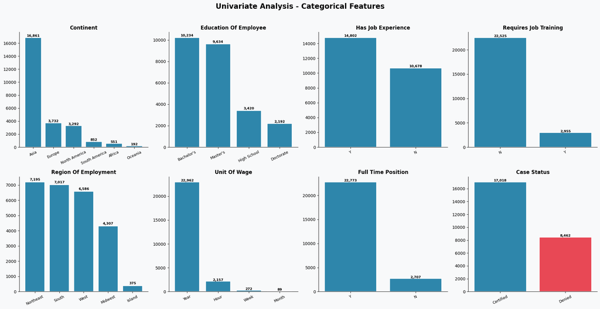

```python
cat_cols = ['continent', 'education_of_employee', 'has_job_experience',
            'requires_job_training', 'region_of_employment',
            'unit_of_wage', 'full_time_position', 'case_status']

fig, axes = plt.subplots(2, 4, figsize=(20, 10))
axes = axes.flatten()

for i, col in enumerate(cat_cols):
    vc = data[col].value_counts()
    color = CERT if col != 'case_status' else [CERT, DENIED]
    axes[i].bar(vc.index, vc.values, color=color, edgecolor='white', linewidth=1.2)
    axes[i].set_title(col.replace('_', ' ').title(), fontweight='bold', fontsize=12)
    axes[i].tick_params(axis='x', rotation=25, labelsize=9)
    axes[i].spines[['top', 'right']].set_visible(False)
    for j, v in enumerate(vc.values):
        axes[i].text(j, v + 100, f'{v:,}', ha='center', fontsize=8, fontweight='bold')

plt.suptitle('Univariate Analysis - Categorical Features',
             fontsize=17, fontweight='bold', y=1.02)
plt.tight_layout()
plt.show()
```

### Univariate Analysis - Numerical Features

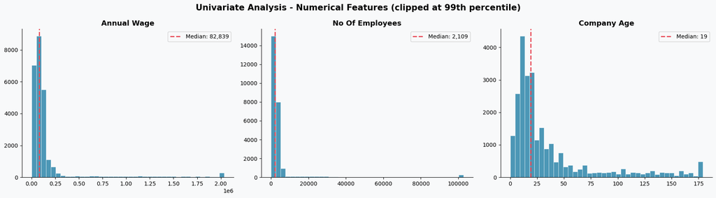

```python
# Standardize all wages to annual
wage_map = {'Hour': 2080, 'Week': 52, 'Month': 12, 'Year': 1}
data['annual_wage'] = data['prevailing_wage'] * data['unit_of_wage'].map(wage_map)
data['company_age'] = 2016 - data['yr_of_estab']

num_cols = ['annual_wage', 'no_of_employees', 'company_age']

fig, axes = plt.subplots(1, 3, figsize=(18, 5))
for i, col in enumerate(num_cols):
    data1 = data[col].clip(upper=data[col].quantile(0.99))
    axes[i].hist(data1, bins=40, color=CERT, edgecolor='white', linewidth=0.5, alpha=0.85)
    axes[i].axvline(data1.median(), color=DENIED, linestyle='--', linewidth=2,
                    label=f'Median: {data1.median():,.0f}')
    axes[i].set_title(col.replace('_', ' ').title(), fontweight='bold', fontsize=13)
    axes[i].legend(fontsize=10)
    axes[i].spines[['top', 'right']].set_visible(False)

plt.suptitle('Univariate Analysis - Numerical Features (clipped at 99th percentile)',
             fontsize=15, fontweight='bold')
plt.tight_layout()
plt.show()
```

### Observations

- Annual Wage: (Median - $82,839) The distribution is heavily right-skewed, with the bulk of applicants concentrated below 250,000 and a long tail stretching out to around 2 million (even after clipping at the 99th percentile).The strong concentration in the lower range with a few extreme outliers suggests a mix of standard professional salaries alongside a small number of highly compensated roles (likely executive or specialized tech positions).
- No of Employees: (Median - 2109) This is the most extremely skewed feature in the dataset. The first bin (near zero) towers at over 14,000 applications — meaning more than half of all filings come from companies with a very small number of employees (relative to the scale)
- Company Age: (Median - 19 years) Unlike the other two features, company age shows a more complex, multi-modal distribution rather than simple skewness. The tallest bar is at approximately 10-15 years, with over 4,000 applications. There is a broad concentration between 10 and 40 years, covering the bulk of the data, and then a gradual decline through older companies.

```python
# Outlier detection using IQR method
print('Outlier Summary (IQR Method):')
print('-' * 75)
for col in ['annual_wage', 'no_of_employees', 'company_age']:
    Q1, Q3 = data[col].quantile(0.25), data[col].quantile(0.75)
    IQR = Q3 - Q1
    lower, upper = Q1 - 1.5 * IQR, Q3 + 1.5 * IQR
    n_out = ((data[col] < lower) | (data[col] > upper)).sum()
    print(f'{col:22s} | {n_out:5,} outliers ({n_out/len(data)*100:5.1f}%)  '
          f'| Range: [{data[col].min():>12,.1f}, {data[col].max():>12,.1f}]')
```

```
Outlier Summary (IQR Method):
---------------------------------------------------------------------------
annual_wage            | 2,387 outliers (  9.4%)  | Range: [       100.0, 14,569,149.4]
no_of_employees        | 1,556 outliers (  6.1%)  | Range: [       -26.0,    602,069.0]
company_age            | 3,260 outliers ( 12.8%)  | Range: [         0.0,        216.0]
```

### Observations

- Annual Wage — 2,387 outliers (9.4%) Nearly one in ten applications has an annual wage flagged as an outlier by the IQR method. All outliers are on the high end since the lower fence falls below zero and wages can't be negative.
- No. of Employees — 1,556 outliers (6.1%) The smallest outlier group at 6.1% of the data. The range extends from -26 (mostly a data entry error) to 602,069.
- Company Age — 3,260 outliers (12.8%) This is the feature with the highest outlier percentage — nearly 1 in 8 applications comes from a company old enough to be flagged. The range spans from 0 (companies established in 2016, the filing year) to 216 years (a company founded around 1800).

### Bivariate Analysis - Features vs Case Certification Status

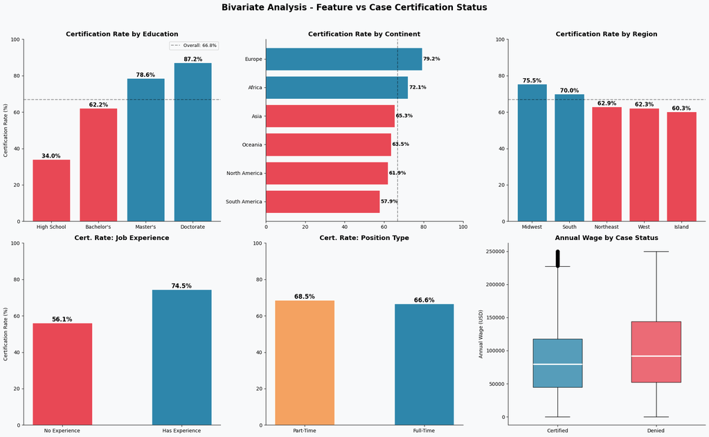

```python
# Bivariate analysis for certification status with various categorical features

fig, axes = plt.subplots(2, 3, figsize=(20, 12))
overall_rate = (data['case_status'] == 'Certified').mean() * 100

# 1. Education
edu_order = ['High School', "Bachelor's", "Master's", 'Doctorate']
edu_pct = data.groupby('education_of_employee')['case_status'].apply(
    lambda x: (x == 'Certified').mean() * 100).reindex(edu_order)
colors = [CERT if v > overall_rate else DENIED for v in edu_pct.values]
axes[0, 0].bar(edu_order, edu_pct.values, color=colors, edgecolor='white')
axes[0, 0].axhline(overall_rate, color='black', linestyle='--', alpha=0.4,
                    label=f'Overall: {overall_rate:.1f}%')
for j, v in enumerate(edu_pct.values):
    axes[0, 0].text(j, v + 0.8, f'{v:.1f}%', ha='center', fontweight='bold', fontsize=11)
axes[0, 0].set_ylim(0, 100)
axes[0, 0].set_title('Certification Rate by Education', fontweight='bold', fontsize=13)
axes[0, 0].set_ylabel('Certification Rate (%)')
axes[0, 0].legend(fontsize=9)
axes[0, 0].spines[['top', 'right']].set_visible(False)

# 2. Continent
cont_pct = data.groupby('continent')['case_status'].apply(
    lambda x: (x == 'Certified').mean() * 100).sort_values()
colors = [CERT if v > overall_rate else DENIED for v in cont_pct.values]
axes[0, 1].barh(cont_pct.index, cont_pct.values, color=colors, edgecolor='white')
axes[0, 1].axvline(overall_rate, color='black', linestyle='--', alpha=0.4)
for j, v in enumerate(cont_pct.values):
    axes[0, 1].text(v + 0.5, j, f'{v:.1f}%', va='center', fontweight='bold', fontsize=10)
axes[0, 1].set_xlim(0, 100)
axes[0, 1].set_title('Certification Rate by Continent', fontweight='bold', fontsize=13)
axes[0, 1].spines[['top', 'right']].set_visible(False)

# 3. Region
reg_pct = data.groupby('region_of_employment')['case_status'].apply(
    lambda x: (x == 'Certified').mean() * 100).sort_values(ascending=False)
colors = [CERT if v > overall_rate else DENIED for v in reg_pct.values]
axes[0, 2].bar(reg_pct.index, reg_pct.values, color=colors, edgecolor='white')
axes[0, 2].axhline(overall_rate, color='black', linestyle='--', alpha=0.4)
for j, v in enumerate(reg_pct.values):
    axes[0, 2].text(j, v + 0.8, f'{v:.1f}%', ha='center', fontweight='bold', fontsize=11)
axes[0, 2].set_ylim(0, 100)
axes[0, 2].set_title('Certification Rate by Region', fontweight='bold', fontsize=13)
axes[0, 2].spines[['top', 'right']].set_visible(False)

# 4. Job Experience
exp_pct = data.groupby('has_job_experience')['case_status'].apply(
    lambda x: (x == 'Certified').mean() * 100)
axes[1, 0].bar(['No Experience', 'Has Experience'],
               [exp_pct['N'], exp_pct['Y']], color=[DENIED, CERT], edgecolor='white', width=0.5)
for j, v in enumerate([exp_pct['N'], exp_pct['Y']]):
    axes[1, 0].text(j, v + 0.8, f'{v:.1f}%', ha='center', fontweight='bold', fontsize=12)
axes[1, 0].set_ylim(0, 100)
axes[1, 0].set_title('Cert. Rate: Job Experience', fontweight='bold', fontsize=13)
axes[1, 0].set_ylabel('Certification Rate (%)')
axes[1, 0].spines[['top', 'right']].set_visible(False)

# 5. Full-Time Position
ft_pct = data.groupby('full_time_position')['case_status'].apply(
    lambda x: (x == 'Certified').mean() * 100)
axes[1, 1].bar(['Part-Time', 'Full-Time'],
               [ft_pct['N'], ft_pct['Y']], color=[GOLD, CERT], edgecolor='white', width=0.5)
for j, v in enumerate([ft_pct['N'], ft_pct['Y']]):
    axes[1, 1].text(j, v + 0.8, f'{v:.1f}%', ha='center', fontweight='bold', fontsize=12)
axes[1, 1].set_ylim(0, 100)
axes[1, 1].set_title('Cert. Rate: Position Type', fontweight='bold', fontsize=13)
axes[1, 1].spines[['top', 'right']].set_visible(False)

# 6. Annual Wage Boxplot
for status, color, pos in [('Certified', CERT, 1), ('Denied', DENIED, 2)]:
    data2 = data[data['case_status'] == status]['annual_wage'].clip(upper=250000)
    bp = axes[1, 2].boxplot(data2, positions=[pos], patch_artist=True, widths=0.5,
                            medianprops=dict(color='white', linewidth=2.5))
    bp['boxes'][0].set_facecolor(color)
    bp['boxes'][0].set_alpha(0.8)
axes[1, 2].set_xticks([1, 2])
axes[1, 2].set_xticklabels(['Certified', 'Denied'])
axes[1, 2].set_title('Annual Wage by Case Status', fontweight='bold', fontsize=13)
axes[1, 2].set_ylabel('Annual Wage (USD)')
axes[1, 2].spines[['top', 'right']].set_visible(False)

plt.suptitle('Bivariate Analysis - Feature vs Case Certification Status',
             fontsize=17, fontweight='bold', y=1.02)
plt.tight_layout()
plt.show()
```

## Q1. What is the distribution of visa case statuses (certified vs. denied)?

The dataset contains 25,480 applications with a clear class imbalance. 17,018 applications (66.8%) were Certified and 8,462 (33.2%) were Denied, giving a ratio of roughly 2:1. This imbalance is important because it means a model that blindly predicts "Certified" for every application would still achieve 66.8% accuracy

## Q2. How does the education level of employees impact visa approval rates?

- High School: 34.0% certification rate (3,420 applicants)
- Bachelor's: 62.2% (10,234 applicants)
- Master's: 78.6% (9,634 applicants)
- Doctorate: 87.2% (2,192 applicants)

## Q3. Is there a significant difference in visa approval rates between employees with and without prior job experience?

Yes, and it's substantial. Applicants with job experience are certified at 74.5% (14,802 applicants) versus 56.1% without experience (10,678 applicants) — an 18.3 percentage point gap. This seems to be the strongest binary predictor in the dataset

## Q4. How does the prevailing wage affect visa approval? Do higher wages lead to higher chances of approval?

No, higher wages are associated with lower approval rates.

- Certified applicants: median annual wage of 79,377
- Denied applicants: median annual wage of 91,827

When we break it into quartiles, the pattern becomes even more striking:

- Q1 (lowest wages): 71.2% certified
- Q2: 69.6% certified
- Q3: 68.5% certified
- Q4 (highest wages): 57.9% certified

## Q5. Do certain regions in the US have higher visa approval rates compared to others?

Yes, with meaningful variation:

- Midwest: 75.5% (highest, 4,307 applications)
- South: 70.0% (7,017 applications)
- Northeast: 62.9% (7,195 applications)
- West: 62.3% (6,586 applications)
- Island: 60.3% (lowest, 375 applications)

## Q6. How does the number of employees in a company influence visa approval? Do larger companies have a higher approval rate?

There is a slight positive trend, but it's statistically weak:

- 1–100 employees: 62.1% certified
- 101–500: 65.5%
- 501–1,000: 66.7%
- 1,000–5,000: 66.6%
- 5,000–10,000: 72.9% (peak)
- 10,000+: 68.5%

## Q7. Are visa approval rates different across various continents of employees? Which continent has the highest and lowest approval rates?

Yes, there's a 21.4 percentage point spread across continents:

- Europe: 79.2% (highest, 3,732 applicants)
- Africa: 72.1% (551 applicants)
- Asia: 65.3% (16,861 applicants — by far the largest group)
- Oceania: 63.5% (192 applicants)
- North America: 61.9% (3,292 applicants)
- South America: 57.9% (lowest, 852 applicants)

### Correlation Heatmap

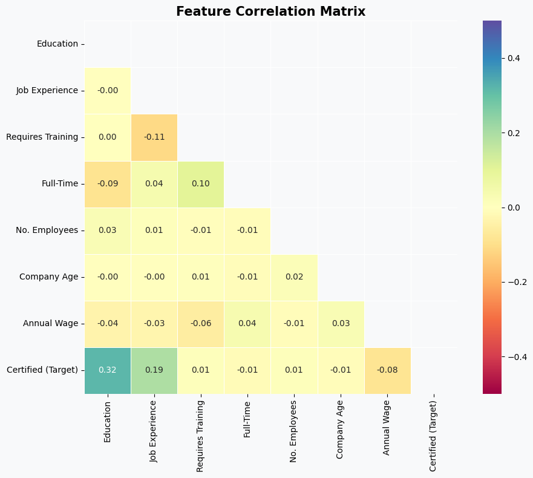

```python
data_corr = data.copy()
data_corr['target'] = (data_corr['case_status'] == 'Certified').astype(int)
data_corr['has_job_experience']    = data_corr['has_job_experience'].map({'Y': 1, 'N': 0})
data_corr['requires_job_training'] = data_corr['requires_job_training'].map({'Y': 1, 'N': 0})
data_corr['full_time_position']    = data_corr['full_time_position'].map({'Y': 1, 'N': 0})
data_corr['edu_enc'] = data_corr['education_of_employee'].map(
    {'High School': 0, "Bachelor's": 1, "Master's": 2, 'Doctorate': 3})

corr_cols = ['edu_enc', 'has_job_experience', 'requires_job_training',
             'full_time_position', 'no_of_employees', 'company_age',
             'annual_wage', 'target']
corr_labels = ['Education', 'Job Experience', 'Requires Training',
               'Full-Time', 'No. Employees', 'Company Age',
               'Annual Wage', 'Certified (Target)']

corr_matrix = data_corr[corr_cols].corr()
corr_matrix.index = corr_labels
corr_matrix.columns = corr_labels

fig, ax = plt.subplots(figsize=(10, 8))
mask = np.triu(np.ones_like(corr_matrix, dtype=bool))
sns.heatmap(corr_matrix, mask=mask, annot=True, fmt='.2f',
            cmap='Spectral', center=0, vmin=-0.5, vmax=0.5,
            linewidths=0.5, ax=ax, square=True)
ax.set_title('Feature Correlation Matrix', fontsize=15, fontweight='bold')
plt.tight_layout()
plt.show()
```

## Observations for Correlations

- Job Experience and Requires Training (r = -0.11): A mild negative relationship. Applicants with prior experience are less likely to require additional job training, which is logically consistent.
- Requires Training and Full-Time Position (r = +0.10): Positions requiring training tend to be full-time roles, suggesting employers invest in training primarily for permanent full-time hires rather than part-time positions.
- Education and Full-Time Position (r = -0.09): A slight negative correlation — higher-educated applicants are somewhat less likely to be in full-time positions. This may reflect that some Doctorate-level applicants fill research or academic roles that can be part-time or project-based.
- Requires Training and Annual Wage (r = -0.06): Roles requiring training tend to have slightly lower prevailing wages, which makes sense as training-required positions are often more junior or entry-level.

# **Data Pre-processing & Feature Engineering**

```python
data_model = data.copy()

# 1. Fix negative employee counts
data_model['no_of_employees'] = data_model['no_of_employees'].clip(lower=0)

# 2. Encode binary features
binary_map = {'Y': 1, 'N': 0}
data_model['has_job_experience']    = data_model['has_job_experience'].map(binary_map)
data_model['requires_job_training'] = data_model['requires_job_training'].map(binary_map)
data_model['full_time_position']    = data_model['full_time_position'].map(binary_map)

# 3. Ordinal encode education
edu_map = {'High School': 0, "Bachelor's": 1, "Master's": 2, 'Doctorate': 3}
data_model['edu_enc'] = data_model['education_of_employee'].map(edu_map)

# 4. Target variable
data_model['target'] = (data_model['case_status'] == 'Certified').astype(int)

# 5. One-hot encode multi-class categoricals
data_model = pd.get_dummies(data_model, columns=['continent', 'region_of_employment'], drop_first=True)

# 6. Assemble feature list
features = (
    ['edu_enc', 'has_job_experience', 'requires_job_training', 'full_time_position',
     'no_of_employees', 'company_age', 'annual_wage']
    + [c for c in data_model.columns if c.startswith('continent_')]
    + [c for c in data_model.columns if c.startswith('region_')]
)

X = data_model[features]
y = data_model['target']

print(f'Feature matrix: {X.shape[0]:,} samples x {X.shape[1]} features')
print(f'\nFeatures ({len(features)}):')
for i, f in enumerate(features):
    print(f'  {i+1:2d}. {f}')
```

```
Feature matrix: 25,480 samples x 16 features

Features (16):
   1. edu_enc
   2. has_job_experience
   3. requires_job_training
   4. full_time_position
   5. no_of_employees
   6. company_age
   7. annual_wage
   8. continent_Asia
   9. continent_Europe
  10. continent_North America
  11. continent_Oceania
  12. continent_South America
  13. region_of_employment_Midwest
  14. region_of_employment_Northeast
  15. region_of_employment_South
  16. region_of_employment_West
```

```python
#Train / Validation / Test Split (60 / 20 / 20)
# Step 1: Split off 20% test set
X_temp, X_test, y_temp, y_test = train_test_split(
    X, y, test_size=0.2, random_state=42, stratify=y
)

# Step 2: Split remaining 80% into 60% train + 20% validation
# 0.25 of 80% = 20% of total
X_train, X_val, y_train, y_val = train_test_split(
    X_temp, y_temp, test_size=0.25, random_state=42, stratify=y_temp
)

print(f'Training set   : {X_train.shape[0]:,} samples  ({X_train.shape[0]/len(X)*100:.0f}%)')
print(f'Validation set : {X_val.shape[0]:,} samples  ({X_val.shape[0]/len(X)*100:.0f}%)')
print(f'Test set       : {X_test.shape[0]:,} samples  ({X_test.shape[0]/len(X)*100:.0f}%)')
print(f'\nClass balance (Certified %):')
print(f'  Train: {y_train.mean():.1%}  |  Val: {y_val.mean():.1%}  |  Test: {y_test.mean():.1%}')
```

```
Training set   : 15,288 samples  (60%)
Validation set : 5,096 samples  (20%)
Test set       : 5,096 samples  (20%)

Class balance (Certified %):
  Train: 66.8%  |  Val: 66.8%  |  Test: 66.8%
```

### SMOTE Oversampling (Training Set Only)

```python
# SMOTE oversampling on the training data set
smote = SMOTE(random_state=42)
X_train_sm, y_train_sm = smote.fit_resample(X_train, y_train)

print(f'Before SMOTE: {X_train.shape[0]:,} samples')
print(f'  Certified: {(y_train==1).sum():,}  |  Denied: {(y_train==0).sum():,}')
print(f'\nAfter SMOTE:  {X_train_sm.shape[0]:,} samples')
print(f'  Certified: {(y_train_sm==1).sum():,}  |  Denied: {(y_train_sm==0).sum():,}')
```

```
Before SMOTE: 15,288 samples
  Certified: 10,211  |  Denied: 5,077

After SMOTE:  20,422 samples
  Certified: 10,211  |  Denied: 10,211
```

### Function to evaluate model and classifers

```python
def get_metrics(y_true, y_pred):
    """Return a dict of all metrics for a given prediction."""
    return {
        'Accuracy':           accuracy_score(y_true, y_pred),
        'Precision (Denied)': precision_score(y_true, y_pred, pos_label=0),
        'Recall (Denied)':    recall_score(y_true, y_pred, pos_label=0),
        'F1 (Denied)':        f1_score(y_true, y_pred, pos_label=0),
        'F1 (Certified)':     f1_score(y_true, y_pred, pos_label=1),
    }

def print_metrics(m):
    print(f'  Accuracy: {m["Accuracy"]:.4f} | Prec(D): {m["Precision (Denied)"]:.4f} | Rec(D): {m["Recall (Denied)"]:.4f} | F1(D): {m["F1 (Denied)"]:.4f} | F1(C): {m["F1 (Certified)"]:.4f}')

def plot_confusion(y_true, y_pred, title='', ax=None):
    cm = confusion_matrix(y_true, y_pred)
    if ax is None: fig, ax = plt.subplots(figsize=(5,4))
    ax.imshow(cm, cmap='Blues')
    ax.set_xticks([0,1]); ax.set_yticks([0,1])
    ax.set_xticklabels(['Denied','Certified'],fontsize=10)
    ax.set_yticklabels(['Denied','Certified'],fontsize=10)
    ax.set_xlabel('Predicted'); ax.set_ylabel('Actual')
    ax.set_title(title, fontweight='bold', fontsize=10)
    for i in range(2):
        for j in range(2):
            ax.text(j,i,f'{cm[i,j]:,}',ha='center',va='center',fontsize=13,fontweight='bold',
                    color='white' if cm[i,j]>cm.max()/2 else 'black')

def run_tuning(name, model, param_grid, X_tr, y_tr, X_v, y_v, X_te, y_te):
    """Run GridSearchCV, print results, return best estimator and metrics."""
    total = np.prod([len(v) if hasattr(v,'__len__') else 1 for v in param_grid.values()])
    print(f'\n{"="*70}')
    print(f'  {name}: {total} combos x 3 folds = {total*3} fits')
    print(f'{"="*70}')

    gs = GridSearchCV(model, param_grid, scoring='f1', cv=3, n_jobs=-1, verbose=1)
    gs.fit(X_tr, y_tr)

    print(f'  Best params: {gs.best_params_}')
    print(f'  Best CV F1:  {gs.best_score_:.4f}')

    best = gs.best_estimator_
    val_m  = get_metrics(y_v,  best.predict(X_v))
    test_m = get_metrics(y_te, best.predict(X_te))

    print(f'  [Validation] ', end=''); print_metrics(val_m)
    print(f'  [Test]       ', end=''); print_metrics(test_m)

    return best, gs.best_params_, gs.best_score_, val_m, test_m

print('Model Evaluation functions defined.')
```

```
Model Evaluation functions defined.
```

# **Model Training and Validation set Evaluation**

## Model Training Original Data Without SMOTE For Validation and Test Data Set

```python
base_models = {
    'Decision Tree': DecisionTreeClassifier(max_depth=8, random_state=1),
    'Bagging':       BaggingClassifier(random_state=1, n_estimators=100),
    'Random Forest': RandomForestClassifier(n_estimators=100, random_state=1),
    'AdaBoost':      AdaBoostClassifier(random_state=1, algorithm='SAMME'),
    'Gradient Boosting': GradientBoostingClassifier(random_state=1),
    'XGBoost':       XGBClassifier(eval_metric='logloss', random_state=1, n_jobs=-1),
}

results_orig_val = {}; results_orig_test = {}
for name, model in base_models.items():
    model.fit(X_train, y_train)
    results_orig_val[name]  = get_metrics(y_val,  model.predict(X_val))
    results_orig_test[name] = get_metrics(y_test, model.predict(X_test))
    print(f'{name:25s} [Val]  ', end=''); print_metrics(results_orig_val[name])
    print(f'{"":25s} [Test] ', end=''); print_metrics(results_orig_test[name])
```

```
Decision Tree             [Val]    Accuracy: 0.7339 | Prec(D): 0.6396 | Rec(D): 0.4560 | F1(D): 0.5324 | F1(C): 0.8140
                          [Test]   Accuracy: 0.7239 | Prec(D): 0.6146 | Rec(D): 0.4515 | F1(D): 0.5206 | F1(C): 0.8061
Bagging                   [Val]    Accuracy: 0.7198 | Prec(D): 0.5978 | Rec(D): 0.4784 | F1(D): 0.5315 | F1(C): 0.8001
                          [Test]   Accuracy: 0.7121 | Prec(D): 0.5801 | Rec(D): 0.4817 | F1(D): 0.5263 | F1(C): 0.7932
Random Forest             [Val]    Accuracy: 0.7223 | Prec(D): 0.6021 | Rec(D): 0.4843 | F1(D): 0.5368 | F1(C): 0.8017
                          [Test]   Accuracy: 0.7172 | Prec(D): 0.5898 | Rec(D): 0.4870 | F1(D): 0.5335 | F1(C): 0.7971
AdaBoost                  [Val]    Accuracy: 0.7304 | Prec(D): 0.6500 | Rec(D): 0.4082 | F1(D): 0.5015 | F1(C): 0.8152
                          [Test]   Accuracy: 0.7231 | Prec(D): 0.6262 | Rec(D): 0.4119 | F1(D): 0.4970 | F1(C): 0.8090
Gradient Boosting         [Val]    Accuracy: 0.7435 | Prec(D): 0.6551 | Rec(D): 0.4814 | F1(D): 0.5550 | F1(C): 0.8198
                          [Test]   Accuracy: 0.7361 | Prec(D): 0.6409 | Rec(D): 0.4663 | F1(D): 0.5399 | F1(C): 0.8150
XGBoost                   [Val]    Accuracy: 0.7312 | Prec(D): 0.6265 | Rec(D): 0.4725 | F1(D): 0.5387 | F1(C): 0.8103
                          [Test]   Accuracy: 0.7223 | Prec(D): 0.6097 | Rec(D): 0.4551 | F1(D): 0.5212 | F1(C): 0.8045
```

```python
orig_val_df = pd.DataFrame(results_orig_val).T.round(4)
orig_val_df.index.name = 'Model'
print('Original Data — Validation Set Summary')
orig_val_df.style.highlight_max(axis=0, color='#006400')
```

```
Original Data — Validation Set Summary
```

| Model | Accuracy | Precision (Denied) | Recall (Denied) | F1 (Denied) | F1 (Certified) |
| --- | --- | --- | --- | --- | --- |
| Decision Tree | 0.733900 | 0.639600 | 0.456000 | 0.532400 | 0.814000 |
| Bagging | 0.719800 | 0.597800 | 0.478400 | 0.531500 | 0.800100 |
| Random Forest | 0.722300 | 0.602100 | 0.484300 | 0.536800 | 0.801700 |
| AdaBoost | 0.730400 | 0.650000 | 0.408200 | 0.501500 | 0.815200 |
| Gradient Boosting | 0.743500 | 0.655100 | 0.481400 | 0.555000 | 0.819800 |
| XGBoost | 0.731200 | 0.626500 | 0.472500 | 0.538700 | 0.810300 |

## Model Training with SMOTE Data for Validation and Test Data Set

```python
smote_models = {
    'Decision Tree': DecisionTreeClassifier(max_depth=8, random_state=1),
    'Bagging':       BaggingClassifier(random_state=1, n_estimators=100),
    'Random Forest': RandomForestClassifier(n_estimators=100, random_state=1),
    'AdaBoost':      AdaBoostClassifier(random_state=1, algorithm='SAMME'),
    'Gradient Boosting': GradientBoostingClassifier(random_state=1),
    'XGBoost':       XGBClassifier(eval_metric='logloss', random_state=1, n_jobs=-1),
}

results_smote_val = {}; results_smote_test = {}; fitted_smote = {}
for name, model in smote_models.items():
    model.fit(X_train_sm, y_train_sm)
    fitted_smote[name] = model
    results_smote_val[name]  = get_metrics(y_val,  model.predict(X_val))
    results_smote_test[name] = get_metrics(y_test, model.predict(X_test))
    print(f'{name:25s} [Val]  ', end=''); print_metrics(results_smote_val[name])
    print(f'{"":25s} [Test] ', end=''); print_metrics(results_smote_test[name])
```

```
Decision Tree             [Val]    Accuracy: 0.7272 | Prec(D): 0.6029 | Rec(D): 0.5245 | F1(D): 0.5610 | F1(C): 0.8022
                          [Test]   Accuracy: 0.7151 | Prec(D): 0.5834 | Rec(D): 0.4959 | F1(D): 0.5361 | F1(C): 0.7944
Bagging                   [Val]    Accuracy: 0.7184 | Prec(D): 0.5846 | Rec(D): 0.5263 | F1(D): 0.5539 | F1(C): 0.7943
                          [Test]   Accuracy: 0.7084 | Prec(D): 0.5673 | Rec(D): 0.5130 | F1(D): 0.5388 | F1(C): 0.7868
Random Forest             [Val]    Accuracy: 0.7196 | Prec(D): 0.5882 | Rec(D): 0.5198 | F1(D): 0.5519 | F1(C): 0.7959
                          [Test]   Accuracy: 0.7123 | Prec(D): 0.5742 | Rec(D): 0.5165 | F1(D): 0.5439 | F1(C): 0.7899
AdaBoost                  [Val]    Accuracy: 0.7074 | Prec(D): 0.5683 | Rec(D): 0.4962 | F1(D): 0.5298 | F1(C): 0.7876
                          [Test]   Accuracy: 0.6943 | Prec(D): 0.5442 | Rec(D): 0.4876 | F1(D): 0.5143 | F1(C): 0.7769
Gradient Boosting         [Val]    Accuracy: 0.7408 | Prec(D): 0.6321 | Rec(D): 0.5257 | F1(D): 0.5740 | F1(C): 0.8137
                          [Test]   Accuracy: 0.7223 | Prec(D): 0.5971 | Rec(D): 0.5035 | F1(D): 0.5463 | F1(C): 0.7999
XGBoost                   [Val]    Accuracy: 0.7200 | Prec(D): 0.5943 | Rec(D): 0.4950 | F1(D): 0.5401 | F1(C): 0.7987
                          [Test]   Accuracy: 0.7151 | Prec(D): 0.5861 | Rec(D): 0.4829 | F1(D): 0.5295 | F1(C): 0.7957
```

```python
smote_val_df = pd.DataFrame(results_smote_val).T.round(4)
smote_val_df.index.name = 'Model'
print('SMOTE Data — Validation Set Summary')
smote_val_df.style.highlight_max(axis=0, color='#006400')
```

```
SMOTE Data — Validation Set Summary
```

| Model | Accuracy | Precision (Denied) | Recall (Denied) | F1 (Denied) | F1 (Certified) |
| --- | --- | --- | --- | --- | --- |
| Decision Tree | 0.727200 | 0.602900 | 0.524500 | 0.561000 | 0.802200 |
| Bagging | 0.718400 | 0.584600 | 0.526300 | 0.553900 | 0.794300 |
| Random Forest | 0.719600 | 0.588200 | 0.519800 | 0.551900 | 0.795900 |
| AdaBoost | 0.707400 | 0.568300 | 0.496200 | 0.529800 | 0.787600 |
| Gradient Boosting | 0.740800 | 0.632100 | 0.525700 | 0.574000 | 0.813700 |
| XGBoost | 0.720000 | 0.594300 | 0.495000 | 0.540100 | 0.798700 |

## Original vs SMOTE Data set Model Comparison for validation data set

```python
comp_rows = []
for name in base_models.keys():
    o = results_orig_val[name]; s = results_smote_val[name]
    comp_rows.append({'Model':name,'Data':'Original','Accuracy':o['Accuracy'],'Recall (Denied)':o['Recall (Denied)'],'F1 (Denied)':o['F1 (Denied)'],'F1 (Certified)':o['F1 (Certified)']})
    comp_rows.append({'Model':name,'Data':'SMOTE','Accuracy':s['Accuracy'],'Recall (Denied)':s['Recall (Denied)'],'F1 (Denied)':s['F1 (Denied)'],'F1 (Certified)':s['F1 (Certified)']})
pd.DataFrame(comp_rows).set_index(['Model','Data']).round(4)
```

| Model | Data | Accuracy | Recall (Denied) | F1 (Denied) | F1 (Certified) |
| --- | --- | --- | --- | --- | --- |
| Decision Tree | Original | 0.7339 | 0.4560 | 0.5324 | 0.8140 |
|  | SMOTE | 0.7272 | 0.5245 | 0.5610 | 0.8022 |
| Bagging | Original | 0.7198 | 0.4784 | 0.5315 | 0.8001 |
|  | SMOTE | 0.7184 | 0.5263 | 0.5539 | 0.7943 |
| Random Forest | Original | 0.7223 | 0.4843 | 0.5368 | 0.8017 |
|  | SMOTE | 0.7196 | 0.5198 | 0.5519 | 0.7959 |
| AdaBoost | Original | 0.7304 | 0.4082 | 0.5015 | 0.8152 |
|  | SMOTE | 0.7074 | 0.4962 | 0.5298 | 0.7876 |
| Gradient Boosting | Original | 0.7435 | 0.4814 | 0.5550 | 0.8198 |
|  | SMOTE | 0.7408 | 0.5257 | 0.5740 | 0.8137 |
| XGBoost | Original | 0.7312 | 0.4725 | 0.5387 | 0.8103 |
|  | SMOTE | 0.7200 | 0.4950 | 0.5401 | 0.7987 |

## Observations

- SMOTE universally improves Denied-class detection.
- AdaBoost is the biggest beneficiary of SMOTE. Its Denied recall jumps from 0.4082 to 0.4962 (+8.8%), the largest gain of any model.
- The accuracy cost of SMOTE is negligible for most models. Gradient Boosting loses only 0.27% accuracy (0.7435 to 0.7408), Random Forest loses 0.27% (0.7223 to 0.7196), and Decision Tree loses 0.67% (0.7339 to 0.7272).
- SMOTE improves both recall and F1 for the Denied class simultaneously.
- Certified-class performance declines modestly but predictably. Certified recall drops by 3-5% across all models after SMOTE.
- Gradient Boosting is the strongest model at both stages.
- XGBoost benefits the least from SMOTE. Its Denied recall only improves by 2.3% (0.4725 to 0.4950), the smallest gain of any model.
- Generalization remains stable after SMOTE. The val-to-test drop is 1-3% for all models under both Original and SMOTE conditionsList item

## Original and SMOTE Comparison for Recall (Denied) & F1 (Denied)

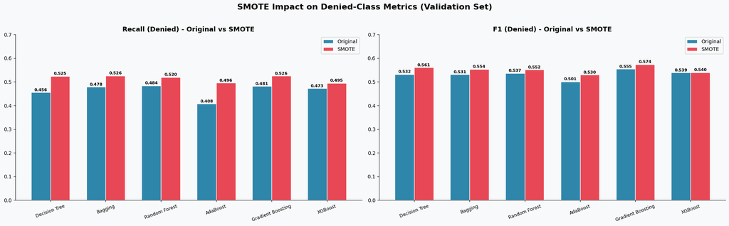

```python
## Original vs SMOTE Comparison for Recall (D) & F1(D)
mnames = list(base_models.keys())
r_orig = [results_orig_val[m]['Recall (Denied)'] for m in mnames]
r_smote = [results_smote_val[m]['Recall (Denied)'] for m in mnames]
x = np.arange(len(mnames)); w = 0.35

fig, axes = plt.subplots(1, 2, figsize=(20, 6))

# Recall
b1 = axes[0].bar(x-w/2, r_orig, w, label='Original', color=CERT, edgecolor='white')
b2 = axes[0].bar(x+w/2, r_smote, w, label='SMOTE', color=DENIED, edgecolor='white')
for b,v in zip(b1,r_orig): axes[0].text(b.get_x()+b.get_width()/2,v+0.005,f'{v:.3f}',ha='center',fontsize=8,fontweight='bold')
for b,v in zip(b2,r_smote): axes[0].text(b.get_x()+b.get_width()/2,v+0.005,f'{v:.3f}',ha='center',fontsize=8,fontweight='bold')
axes[0].set_xticks(x); axes[0].set_xticklabels(mnames,rotation=20,fontsize=9)
axes[0].set_title('Recall (Denied) - Original vs SMOTE',fontweight='bold',fontsize=13)
axes[0].legend(); axes[0].set_ylim(0,0.7); axes[0].spines[['top','right']].set_visible(False)

# F1
f1_o = [results_orig_val[m]['F1 (Denied)'] for m in mnames]
f1_s = [results_smote_val[m]['F1 (Denied)'] for m in mnames]
b1 = axes[1].bar(x-w/2, f1_o, w, label='Original', color=CERT, edgecolor='white')
b2 = axes[1].bar(x+w/2, f1_s, w, label='SMOTE', color=DENIED, edgecolor='white')
for b,v in zip(b1,f1_o): axes[1].text(b.get_x()+b.get_width()/2,v+0.005,f'{v:.3f}',ha='center',fontsize=8,fontweight='bold')
for b,v in zip(b2,f1_s): axes[1].text(b.get_x()+b.get_width()/2,v+0.005,f'{v:.3f}',ha='center',fontsize=8,fontweight='bold')
axes[1].set_xticks(x); axes[1].set_xticklabels(mnames,rotation=20,fontsize=9)
axes[1].set_title('F1 (Denied) - Original vs SMOTE',fontweight='bold',fontsize=13)
axes[1].legend(); axes[1].set_ylim(0,0.7); axes[1].spines[['top','right']].set_visible(False)

plt.suptitle('SMOTE Impact on Denied-Class Metrics (Validation Set)', fontsize=16, fontweight='bold', y=1.02)
plt.tight_layout(); plt.show()
```

### Observations

Recall (Denied)

- Every bar grows taller after SMOTE.The gap between models narrows after SMOTE.
- AdaBoost shows the most dramatic visual transformation. XGBoost shows the smallest visual change.
- Three models cluster at the top after SMOTE. Decision Tree (0.525), Bagging (0.526), and Gradient Boosting (0.526) all converge to nearly identical Denied recall after SMOTE

F1 (Denied)

- F1 improvements confirm the recall gains are genuine.The F1 gains are smaller than the recall gains.
- Gradient Boosting dominates both bars. It has the highest Original F1 (0.555) and the highest SMOTE F1 (0.574), leading the field in both conditions.
- AdaBoost has the weakest F1 in both conditions.Decision Tree achieves the largest F1 jump. Its F1 (Denied) rises from 0.532 to 0.561 (+2.9%), the biggest F1 improvement on the chart.

Recall shows how many denials each model catches. F1 shows how efficiently it catches them (balancing false flags against missed denials).

# **Model Performance Improvement**

## Hyperparameter Tuning Using GridSearchCV for All Models (SMOTE Data)

Each model is tuned using the specified sample parameter grids on the SMOTE-balanced training data.

```python
# Store all tuning results
tuned_results = {}
```

#### Decision Tree

```python
best_dt, bp_dt, cv_dt, val_dt, test_dt = run_tuning(
    'Decision Tree',
    DecisionTreeClassifier(random_state=1),
    {
        'max_depth': np.arange(3, 8),
        'min_samples_leaf': [1, 2, 4, 7],
        'max_leaf_nodes': [15, 20, 25, 30],
        'min_impurity_decrease': [0.0001, 0.0005, 0.001, 0.005],
    },
    X_train_sm, y_train_sm, X_val, y_val, X_test, y_test
)
tuned_results['Decision Tree'] = {'best': best_dt, 'params': bp_dt, 'cv_f1': cv_dt, 'val': val_dt, 'test': test_dt}
```

```
======================================================================
  Decision Tree: 320 combos x 3 folds = 960 fits
======================================================================
Fitting 3 folds for each of 320 candidates, totalling 960 fits
  Best params: {'max_depth': np.int64(7), 'max_leaf_nodes': 30, 'min_impurity_decrease': 0.0001, 'min_samples_leaf': 1}
  Best CV F1:  0.7749
  [Validation]   Accuracy: 0.7255 | Prec(D): 0.5957 | Rec(D): 0.5405 | F1(D): 0.5667 | F1(C): 0.7991
  [Test]         Accuracy: 0.7214 | Prec(D): 0.5903 | Rec(D): 0.5254 | F1(D): 0.5560 | F1(C): 0.7970
```

### Observations

- Denied recall jumps from 0.5245 (SMOTE baseline) to 0.5405 on validation
- Accuracy drops from 0.7272 to 0.7255, indicating the model is trading overall correctness for better Denied detection

#### Bagging Classifier

```python
best_bag, bp_bag, cv_bag, val_bag, test_bag = run_tuning(
    'Bagging Classifier',
    BaggingClassifier(random_state=1),
    {
        'max_samples': [0.5, 0.6, 0.7, 0.8, 0.9],
        'max_features': [0.4, 0.5, 0.6, 0.7, 0.8],
        'n_estimators': [70, 100, 150, 200],
    },
    X_train_sm, y_train_sm, X_val, y_val, X_test, y_test
)
tuned_results['Bagging'] = {'best': best_bag, 'params': bp_bag, 'cv_f1': cv_bag, 'val': val_bag, 'test': test_bag}
```

```
======================================================================
  Bagging Classifier: 100 combos x 3 folds = 300 fits
======================================================================
Fitting 3 folds for each of 100 candidates, totalling 300 fits
  Best params: {'max_features': 0.6, 'max_samples': 0.6, 'n_estimators': 200}
  Best CV F1:  0.8013
  [Validation]   Accuracy: 0.7168 | Prec(D): 0.5895 | Rec(D): 0.4861 | F1(D): 0.5329 | F1(C): 0.7968
  [Test]         Accuracy: 0.7170 | Prec(D): 0.5919 | Rec(D): 0.4758 | F1(D): 0.5275 | F1(C): 0.7980
```

### Observations

#### Random Forest

```python
best_rf, bp_rf, cv_rf, val_rf, test_rf = run_tuning(
    'Random Forest',
    RandomForestClassifier(random_state=1, n_jobs=-1),
    {
        'n_estimators': [100, 150, 200, 250],
        'min_samples_leaf': [2, 3, 4, 5],
        'max_features': [0.15, 0.2, 0.25, 0.3, 0.35],
        'max_samples': [0.5, 0.6, 0.7, 0.8],
    },
    X_train_sm, y_train_sm, X_val, y_val, X_test, y_test
)
tuned_results['Random Forest'] = {'best': best_rf, 'params': bp_rf, 'cv_f1': cv_rf, 'val': val_rf, 'test': test_rf}
```

```
======================================================================
  Random Forest: 320 combos x 3 folds = 960 fits
======================================================================
Fitting 3 folds for each of 320 candidates, totalling 960 fits
  Best params: {'max_features': 0.25, 'max_samples': 0.6, 'min_samples_leaf': 3, 'n_estimators': 150}
  Best CV F1:  0.7973
  [Validation]   Accuracy: 0.7392 | Prec(D): 0.6252 | Rec(D): 0.5369 | F1(D): 0.5777 | F1(C): 0.8114
  [Test]         Accuracy: 0.7378 | Prec(D): 0.6213 | Rec(D): 0.5390 | F1(D): 0.5772 | F1(C): 0.8100
```

### Observations

- Validation F1 (Denied) rises from 0.5519 (SMOTE baseline) to 0.5777 (+2.5%).
- Test F1 reaches 0.5772.

#### Ada Boost

```python
best_ada, bp_ada, cv_ada, val_ada, test_ada = run_tuning(
    'AdaBoost',
    AdaBoostClassifier(random_state=1, algorithm='SAMME'),
    {
        'n_estimators': [100, 150, 200, 300],
        'learning_rate': [0.05, 0.1, 0.15, 0.2, 0.3],
        'estimator': [
            DecisionTreeClassifier(max_depth=3, random_state=1),
            DecisionTreeClassifier(max_depth=4, random_state=1),
            DecisionTreeClassifier(max_depth=5, random_state=1),
        ],
    },
    X_train_sm, y_train_sm, X_val, y_val, X_test, y_test
)
tuned_results['AdaBoost'] = {'best': best_ada, 'params': bp_ada, 'cv_f1': cv_ada, 'val': val_ada, 'test': test_ada}
```

```
======================================================================
  AdaBoost: 60 combos x 3 folds = 180 fits
======================================================================
Fitting 3 folds for each of 60 candidates, totalling 180 fits
  Best params: {'estimator': DecisionTreeClassifier(max_depth=5, random_state=1), 'learning_rate': 0.15, 'n_estimators': 300}
  Best CV F1:  0.7956
  [Validation]   Accuracy: 0.7406 | Prec(D): 0.6239 | Rec(D): 0.5517 | F1(D): 0.5856 | F1(C): 0.8112
  [Test]         Accuracy: 0.7290 | Prec(D): 0.6043 | Rec(D): 0.5325 | F1(D): 0.5661 | F1(C): 0.8030
```

### Observations

#### Gradient Boosting

```python
best_gb, bp_gb, cv_gb, val_gb, test_gb = run_tuning(
    'Gradient Boosting',
    GradientBoostingClassifier(random_state=1),
    {
        'init': [AdaBoostClassifier(random_state=1, algorithm='SAMME'),
                 DecisionTreeClassifier(random_state=1)],
        'n_estimators': [100, 150, 200, 300],
        'learning_rate': [0.05, 0.1, 0.15, 0.2],
        'subsample': [0.8, 0.9, 1.0],
        'max_features': [0.5, 0.7, 0.9],
        'max_depth': [3, 4, 5],
    },
    X_train_sm, y_train_sm, X_val, y_val, X_test, y_test
)
tuned_results['Gradient Boosting'] = {'best': best_gb, 'params': bp_gb, 'cv_f1': cv_gb, 'val': val_gb, 'test': test_gb}
```

```
======================================================================
  Gradient Boosting: 864 combos x 3 folds = 2592 fits
======================================================================
Fitting 3 folds for each of 864 candidates, totalling 2592 fits
  Best params: {'init': AdaBoostClassifier(algorithm='SAMME', random_state=1), 'learning_rate': 0.05, 'max_depth': 5, 'max_features': 0.9, 'n_estimators': 200, 'subsample': 0.9}
  Best CV F1:  0.7987
  [Validation]   Accuracy: 0.7422 | Prec(D): 0.6332 | Rec(D): 0.5322 | F1(D): 0.5783 | F1(C): 0.8143
  [Test]         Accuracy: 0.7288 | Prec(D): 0.6070 | Rec(D): 0.5195 | F1(D): 0.5599 | F1(C): 0.8040
```

### Observations

- Despite being the dominant model at both previous stages (Original and SMOTE baselines), Gradient Boosting barely improves with tuning — validation F1 (Denied) increases marginally from 0.5740 to 0.5783 (0.3%)
- Test F1 improves from 0.5463 to 0.5599 (1.2%).

#### XG Boost

```python
best_xgb, bp_xgb, cv_xgb, val_xgb, test_xgb = run_tuning(
    'XGBoost',
    XGBClassifier(eval_metric='logloss', random_state=1, n_jobs=-1, tree_method='hist'),
    {
        'n_estimators': [100, 200, 300],
        'max_depth': [3, 4, 5, 6],
        'learning_rate': [0.01, 0.03, 0.05, 0.1],
        'gamma': [0, 0.1, 0.5, 1],
        'subsample': [0.7, 0.8, 0.9],
        'colsample_bytree': [0.5, 0.7, 0.9],
    },
    X_train_sm, y_train_sm, X_val, y_val, X_test, y_test
)
tuned_results['XGBoost'] = {'best': best_xgb, 'params': bp_xgb, 'cv_f1': cv_xgb, 'val': val_xgb, 'test': test_xgb}
```

```
======================================================================
  XGBoost: 1728 combos x 3 folds = 5184 fits
======================================================================
Fitting 3 folds for each of 1728 candidates, totalling 5184 fits
  Best params: {'colsample_bytree': 0.9, 'gamma': 0.1, 'learning_rate': 0.03, 'max_depth': 6, 'n_estimators': 200, 'subsample': 0.9}
  Best CV F1:  0.8009
  [Validation]   Accuracy: 0.7435 | Prec(D): 0.6344 | Rec(D): 0.5381 | F1(D): 0.5823 | F1(C): 0.8150
  [Test]         Accuracy: 0.7310 | Prec(D): 0.6122 | Rec(D): 0.5177 | F1(D): 0.5610 | F1(C): 0.8061
```

### Observations

- Denied recall improves from 0.4950 (SMOTE baseline) to 0.5381 on validation and 0.5177 on test.
- F1 (Denied) improves from 0.5401 to 0.5823(validation) and from 0.5295 to 0.5610 (test).

### Stacking Classifier

```python
stacking = StackingClassifier(
    estimators=[
        ('rf', RandomForestClassifier(n_estimators=100,max_depth=10,random_state=1,n_jobs=-1)),
        ('gb', GradientBoostingClassifier(n_estimators=100,max_depth=4,learning_rate=0.1,random_state=1)),
        ('xgb', XGBClassifier(n_estimators=100,max_depth=4,learning_rate=0.1,eval_metric='logloss',random_state=1,n_jobs=-1)),
    ],
    final_estimator=DecisionTreeClassifier(max_depth=6, random_state=1), cv=3, n_jobs=-1)
stacking.fit(X_train_sm, y_train_sm)
stack_val  = get_metrics(y_val,  stacking.predict(X_val))
stack_test = get_metrics(y_test, stacking.predict(X_test))
print('Stacking (SMOTE) — Val:  ', end=''); print_metrics(stack_val)
print('Stacking (SMOTE) — Test: ', end=''); print_metrics(stack_test)
```

```
Stacking (SMOTE) — Val:    Accuracy: 0.7439 | Prec(D): 0.6422 | Rec(D): 0.5174 | F1(D): 0.5731 | F1(C): 0.8171
Stacking (SMOTE) — Test:   Accuracy: 0.7302 | Prec(D): 0.6141 | Rec(D): 0.5041 | F1(D): 0.5537 | F1(C): 0.8066
```

### Observations

- Stacking achieves the highest validation accuracy of any model in the entire analysis.
- Stacking does not outperform the best individual tuned model on the metric that matters most.

# **Model Comparison and Final Model Selection**

## Grand Comparison for all stages

```python
grand = []
for name in base_models.keys():
    ov = results_orig_val[name]; ot = results_orig_test[name]
    sv = results_smote_val[name]; st = results_smote_test[name]
    grand.append({'Model':name,'Stage':'1. Original','Val Acc':ov['Accuracy'],'Val Rec(D)':ov['Recall (Denied)'],'Val F1(D)':ov['F1 (Denied)'],'Test Acc':ot['Accuracy'],'Test Rec(D)':ot['Recall (Denied)'],'Test F1(D)':ot['F1 (Denied)']})
    grand.append({'Model':name,'Stage':'2. SMOTE','Val Acc':sv['Accuracy'],'Val Rec(D)':sv['Recall (Denied)'],'Val F1(D)':sv['F1 (Denied)'],'Test Acc':st['Accuracy'],'Test Rec(D)':st['Recall (Denied)'],'Test F1(D)':st['F1 (Denied)']})

for name, tr in tuned_results.items():
    grand.append({'Model':name,'Stage':'3. SMOTE+Tuned','Val Acc':tr['val']['Accuracy'],'Val Rec(D)':tr['val']['Recall (Denied)'],'Val F1(D)':tr['val']['F1 (Denied)'],'Test Acc':tr['test']['Accuracy'],'Test Rec(D)':tr['test']['Recall (Denied)'],'Test F1(D)':tr['test']['F1 (Denied)']})

grand.append({'Model':'Stacking','Stage':'2. SMOTE','Val Acc':stack_val['Accuracy'],'Val Rec(D)':stack_val['Recall (Denied)'],'Val F1(D)':stack_val['F1 (Denied)'],'Test Acc':stack_test['Accuracy'],'Test Rec(D)':stack_test['Recall (Denied)'],'Test F1(D)':stack_test['F1 (Denied)']})

grand_df = pd.DataFrame(grand).round(4).set_index(['Stage','Model'])
grand_df.style.highlight_max(axis=0, color='#006400')
```

| Stage | Model | Val Acc | Val Rec(D) | Val F1(D) | Test Acc | Test Rec(D) | Test F1(D) |
| --- | --- | --- | --- | --- | --- | --- | --- |
| 1. Original | Decision Tree | 0.733900 | 0.456000 | 0.532400 | 0.723900 | 0.451500 | 0.520600 |
| 2. SMOTE | Decision Tree | 0.727200 | 0.524500 | 0.561000 | 0.715100 | 0.495900 | 0.536100 |
| 1. Original | Bagging | 0.719800 | 0.478400 | 0.531500 | 0.712100 | 0.481700 | 0.526300 |
| 2. SMOTE | Bagging | 0.718400 | 0.526300 | 0.553900 | 0.708400 | 0.513000 | 0.538800 |
| 1. Original | Random Forest | 0.722300 | 0.484300 | 0.536800 | 0.717200 | 0.487000 | 0.533500 |
| 2. SMOTE | Random Forest | 0.719600 | 0.519800 | 0.551900 | 0.712300 | 0.516500 | 0.543900 |
| 1. Original | AdaBoost | 0.730400 | 0.408200 | 0.501500 | 0.723100 | 0.411900 | 0.497000 |
| 2. SMOTE | AdaBoost | 0.707400 | 0.496200 | 0.529800 | 0.694300 | 0.487600 | 0.514300 |
| 1. Original | Gradient Boosting | 0.743500 | 0.481400 | 0.555000 | 0.736100 | 0.466300 | 0.539900 |
| 2. SMOTE | Gradient Boosting | 0.740800 | 0.525700 | 0.574000 | 0.722300 | 0.503500 | 0.546300 |
| 1. Original | XGBoost | 0.731200 | 0.472500 | 0.538700 | 0.722300 | 0.455100 | 0.521200 |
| 2. SMOTE | XGBoost | 0.720000 | 0.495000 | 0.540100 | 0.715100 | 0.482900 | 0.529500 |
| 3. SMOTE+Tuned | Decision Tree | 0.725500 | 0.540500 | 0.566700 | 0.721400 | 0.525400 | 0.556000 |
|  | Bagging | 0.716800 | 0.486100 | 0.532900 | 0.717000 | 0.475800 | 0.527500 |
|  | Random Forest | 0.739200 | 0.536900 | 0.577700 | 0.737800 | 0.539000 | 0.577200 |
|  | AdaBoost | 0.740600 | 0.551700 | 0.585600 | 0.729000 | 0.532500 | 0.566100 |
|  | Gradient Boosting | 0.742200 | 0.532200 | 0.578300 | 0.728800 | 0.519500 | 0.559900 |
|  | XGBoost | 0.743500 | 0.538100 | 0.582300 | 0.731000 | 0.517700 | 0.561000 |
| 2. SMOTE | Stacking | 0.743900 | 0.517400 | 0.573100 | 0.730200 | 0.504100 | 0.553700 |

### Confusion Matrix - Tuned Models (Test Set)

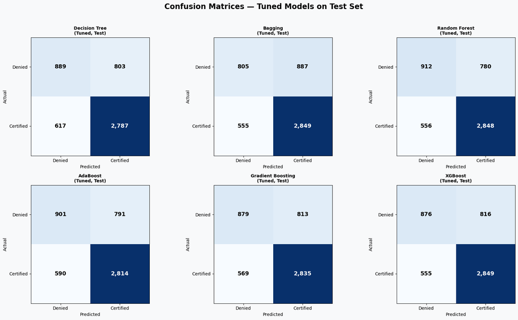

```python
fig, axes = plt.subplots(2, 3, figsize=(18, 10))
axes_f = axes.flatten()
for i, (name, tr) in enumerate(tuned_results.items()):
    plot_confusion(y_test, tr['best'].predict(X_test), title=f'{name}\n(Tuned, Test)', ax=axes_f[i])
plt.suptitle('Confusion Matrices — Tuned Models on Test Set', fontsize=17, fontweight='bold', y=1.02)
plt.tight_layout(); plt.show()
```

### Observations

- Random Forest correctly identifies 912 out of 1,692 denied applications (53.9%) — the highest TN count of any model. It misses 780 denials, the fewest missed by any model.
- AdaBoost catches 901 denials (53.2%) — only 11 fewer than Random Forest. However, it generates 590 false negatives (legitimate certified applications wrongly flagged as denied), compared to Random Forest's 556.
- Despite being the simplest model (a single tree), Decision Tree catches 889 denials — only 23 fewer than Random Forest and 12 fewer than AdaBoost. However, its weakness shows in the false negative count: 617 certified applications are wrongly flagged, the highest of any model.
- Gradient Boosting and XGBoost are nearly identical — differing by only 3 denials caught and 14 false flags.

### Feature Importances - Best Tuned Models

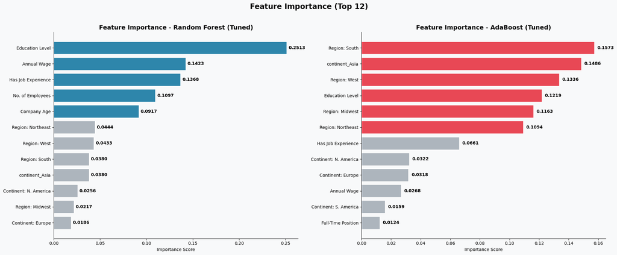

```python
readable = {'annual_wage':'Annual Wage','company_age':'Company Age','no_of_employees':'No. of Employees',
    'edu_enc':'Education Level','has_job_experience':'Has Job Experience','requires_job_training':'Requires Training',
    'full_time_position':'Full-Time Position','continent_Europe':'Continent: Europe',
    'continent_North America':'Continent: N. America','continent_Oceania':'Continent: Oceania',
    'continent_South America':'Continent: S. America','continent_Africa':'Continent: Africa',
    'region_of_employment_Northeast':'Region: Northeast','region_of_employment_South':'Region: South',
    'region_of_employment_West':'Region: West','region_of_employment_Island':'Region: Island',
    'region_of_employment_Midwest':'Region: Midwest'}

fig, axes = plt.subplots(1, 2, figsize=(20, 8))
for ax, (title, mdl, color) in zip(axes, [
    ('Random Forest (Tuned)', best_rf, CERT),
    ('AdaBoost (Tuned)', best_ada, DENIED)
]):
    fi = pd.Series(mdl.feature_importances_, index=features).sort_values(ascending=False)
    fi.index = [readable.get(i,i) for i in fi.index]
    fi_plot = fi.sort_values().tail(12)
    bar_colors = [color if v>fi_plot.mean() else '#adb5bd' for v in fi_plot.values]
    bars = ax.barh(fi_plot.index, fi_plot.values, color=bar_colors, edgecolor='white')
    for b,v in zip(bars, fi_plot.values):
        ax.text(v+0.002, b.get_y()+b.get_height()/2, f'{v:.4f}', va='center', fontsize=10, fontweight='bold')
    ax.set_title(f'Feature Importance - {title}', fontsize=14, fontweight='bold')
    ax.set_xlabel('Importance Score'); ax.spines[['top','right']].set_visible(False)
plt.suptitle('Feature Importance (Top 12)', fontsize=17, fontweight='bold', y=1.02)
plt.tight_layout(); plt.show()
```

## Final Conclusions

This analysis evaluated six classification models across three stages —

- Original (imbalanced) data
- SMOTE-balanced data
- SMOTE with hyperparameter tuning

Using a 60/20/20 train-validation-test split to ensure unbiased performance estimates.

# **Actionable Insights and Recommendations**

### Recommendations

For Immediate Deployment:

Deploy the Random Forest (SMOTE + Tuned) model as a pre-screening tool that assigns a risk score to each incoming application. Applications scoring below the 0.5 predicted-probability threshold get flagged for priority human review. Based on the test set performance, this would correctly flag 912 out of every 1,692 applications that should be denied, while incorrectly flagging 556 legitimate applications.AdaBoost (SMOTE + Tuned) should be maintained as a backup model, particularly if OFLC's operational priority shifts toward maximizing denial detection over reviewer efficiency.

For Operational Efficiency:

Create a three-tier review pipeline based on model confidence:

Auto-certify (predicted probability > 0.85): High-education, experienced applicants from well-established employers with properly benchmarked wages. These have historically high certification rates and can be fast-tracked with minimal review.

Standard review (0.40 - 0.85): The bulk of applications where the model is uncertain. These proceed through the normal review process.

Priority review (predicted probability < 0.40): Applications the model is most confident should be denied — low education, no experience, inflated wages, or unusual employer profiles. These should be reviewed first and most carefully.

For Model Maintenance:

Retrain the model annually using the most recent fiscal year's data. Labor market conditions, OFLC policy interpretations, and applicant profiles shift over time, and a model trained on 2016 data will drift. Monitor the Denied-class recall monthly — if it drops below 45% on new data, that's the signal to retrigger a full retraining cycle.

```python
!jupyter nbconvert /content/drive/MyDrive/notebooks_data/EasyVisa_Project/Advanced_ML_Project_EasyVisa_Jan26_DebasishNanda_001 --to html
```

[output not shown]